# TE analysis in 2cell embryos injected and nonInjected w active/dead-Btgh

Sara Formichetti

EMBL Rome  
sara.formichetti@embl.it

February 22nd, 2022

# 1 Reading the data

# 2 Analysis at family level

## 2.1 FPKM for each family of Repetitive Elements

For each family of Repetitive Elements (in case of elements with no repFamily name or repFamilies belonging to more than one repClass I use repClass) I compute **FPKM** values, as follows: for each sample:

- I compute the sum of counts for all elements belonging to that repFamily
- I divide this sum by the total number of reads for that sample and multiply by 10⁶
- I divide this number by the total sum of lengths (in Kb) of the elements belonging to that repFamily –> FPKM
- When specified, **I subtract from each FPKM the total FPKM of all transposons belonging to the DNA repClass**

## 2.2 Heatmaps

The heatmaps are scaled by rows.

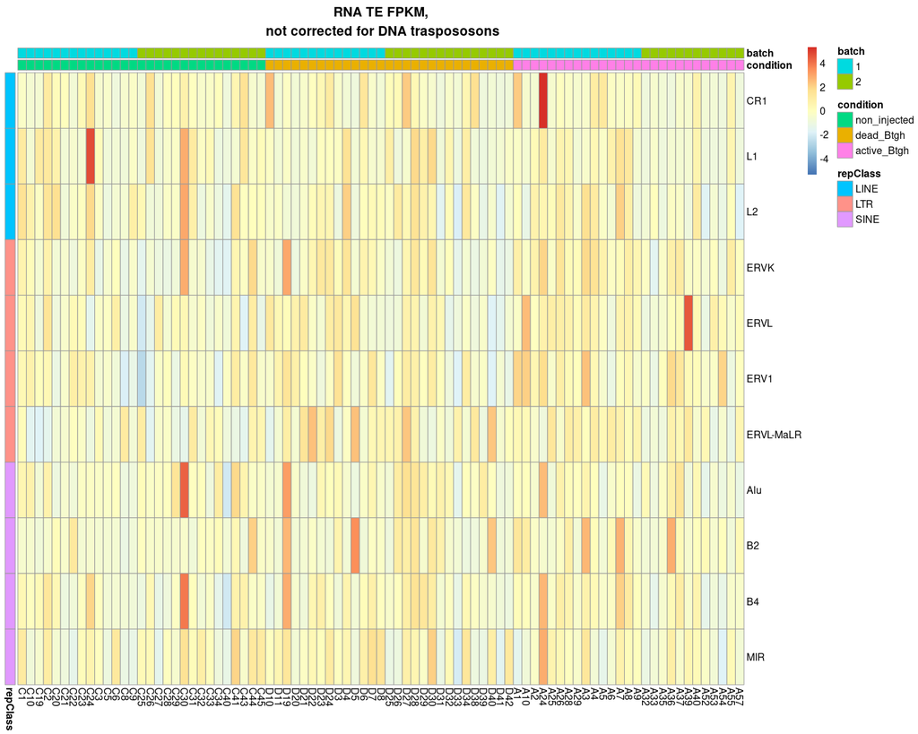

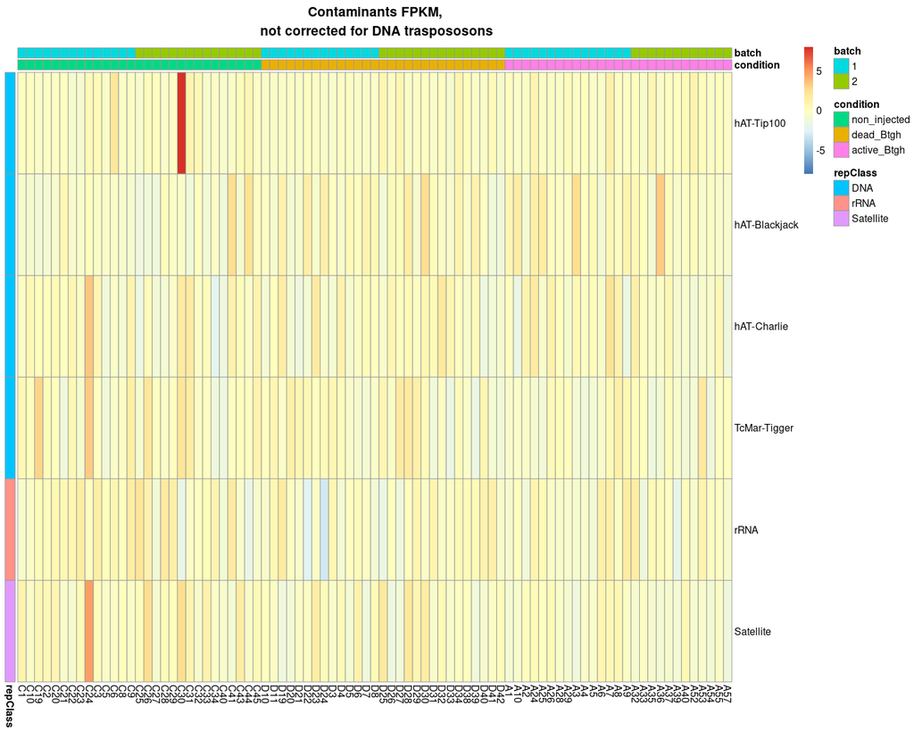

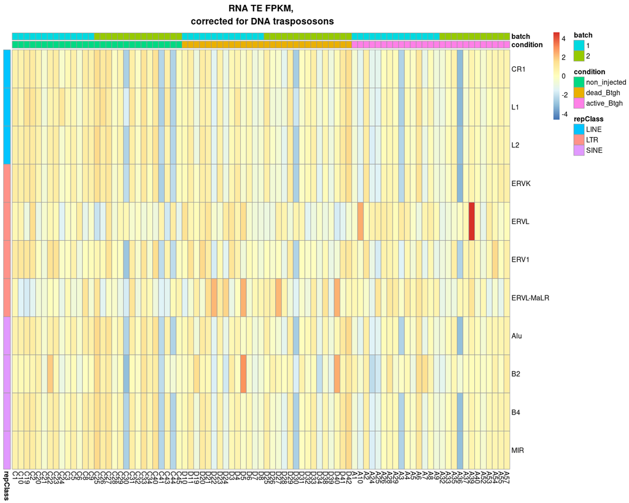

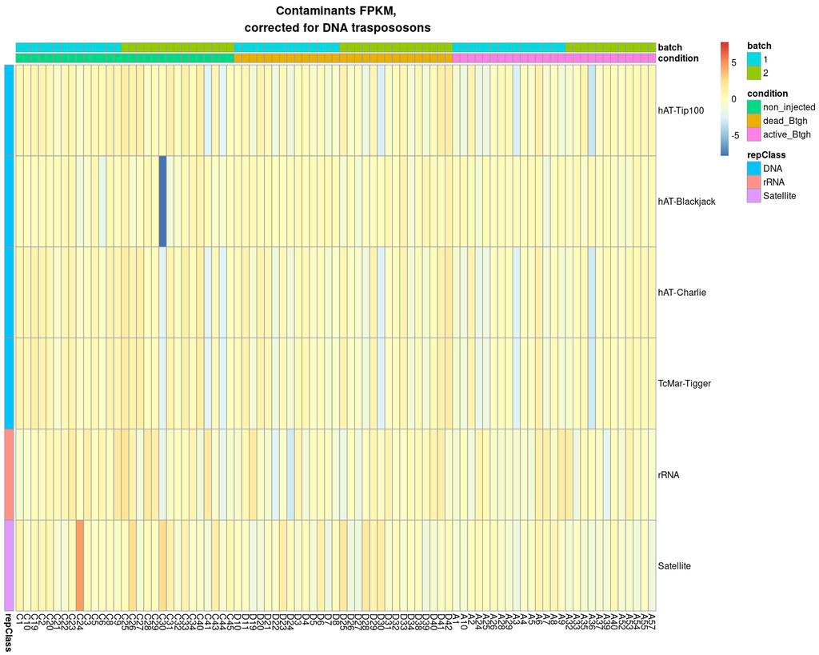

No samples showing particularly abundant DNA contamination nor RNA TE families showing deregulation in one of the three experimental groups.

# 3 DE-Seq analysis of RNA transposons

I include the FPKM of DNA transposons as confounding factor in DESeq2 formula.

Before running the Differential Expression analysis, the data are pre-filtered to remove all repetitive elements with < 10 reads among all samples.

## 3.1 DESeq2-normalized counts of EGA TEs per condition

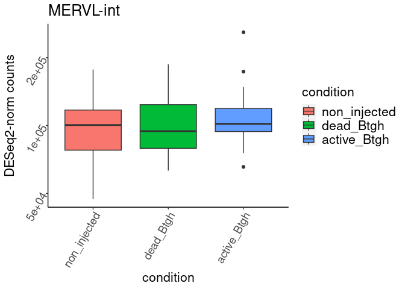

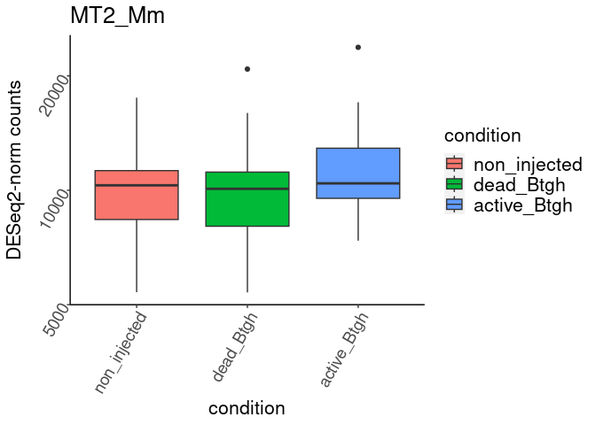

## 3.2 MA-plots

- The threshold used for a dot to be coloured in the MA-plots is p-value adjusted < 0.1.
- Transposable elements whose mean expression > 10 and log2FoldChange > 0.2 (or < -0.2) are labeled.

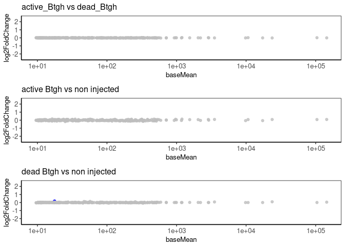